# lab3c_1.3

## Hubble Data

```
## Rows: 24
## Columns: 2
## $ distance           <dbl> 0.032, 0.034, 0.214, 0.263, 0.275, 0.275, 0.450, 0…
## $ recession_velocity <dbl> 170, 290, -130, -70, -185, -220, 200, 290, 270, 20…
```

## Question 1.

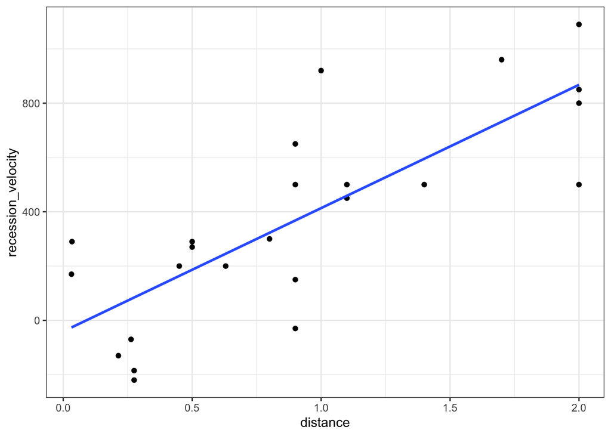

## Question 2.

**Does the regression make sense with the constant term = 0? (if the distance from the earth is zero, is the velocity from the earth 0?) Fit the model allowing for an intercept and test the null hypothesis that the intercept is equal to zero. Fit another regression that does not allow an intercept and write down your estimate for Hubble’s constant. You can force the regression line to have a zero intercept by putting a -1 in the model formula, e.g. lm(y ~ x - 1)**

```
##
## Call:
## lm(formula = recession_velocity ~ distance, data = hubble)
##
## Residuals:
##     Min      1Q  Median      3Q     Max
## -397.96 -158.10  -13.16  148.09  506.63
##
## Coefficients:
##             Estimate Std. Error t value Pr(>|t|)
## (Intercept)   -40.78      83.44  -0.489     0.63
## distance      454.16      75.24   6.036 4.48e-06 ***
## ---
## Signif. codes:  0 '***' 0.001 '**' 0.01 '*' 0.05 '.' 0.1 ' ' 1
##
## Residual standard error: 232.9 on 22 degrees of freedom
## Multiple R-squared:  0.6235, Adjusted R-squared:  0.6064
## F-statistic: 36.44 on 1 and 22 DF,  p-value: 4.477e-06
```

- $H_0: \beta_0 = 0$ vs. $H_1: \beta_0 \neq 0$
- Assumption: The residuals are iid $N(0,\sigma^2)$ and there is a linear relationship between y and x
- Observed test statistic: $t_0 = -0.489$
- p_value $= 2P(t_{n-2}\geq |t_0|) = 2P(t_{n22}\geq 0.489) = 0.63$
- Conclusion: We do not reject $H_0$, therefore, the intercept is not far from 0.

We can also force the intercept to be at 0. We do this because it is dicated by underlying physics that the model is trying to describe.

```
##
## Call:
## lm(formula = recession_velocity ~ distance - 1, data = hubble)
##
## Residuals:
##    Min     1Q Median     3Q    Max
## -411.5 -191.3   -7.1  128.0  496.1
##
## Coefficients:
##          Estimate Std. Error t value Pr(>|t|)
## distance   423.94      42.15   10.06 6.87e-10 ***
## ---
## Signif. codes:  0 '***' 0.001 '**' 0.01 '*' 0.05 '.' 0.1 ' ' 1
##
## Residual standard error: 229 on 23 degrees of freedom
## Multiple R-squared:  0.8147, Adjusted R-squared:  0.8067
## F-statistic: 101.1 on 1 and 23 DF,  p-value: 6.869e-10
```

## Question 3.

**Generate plots to check for equal variance and the normality of the residuals.**

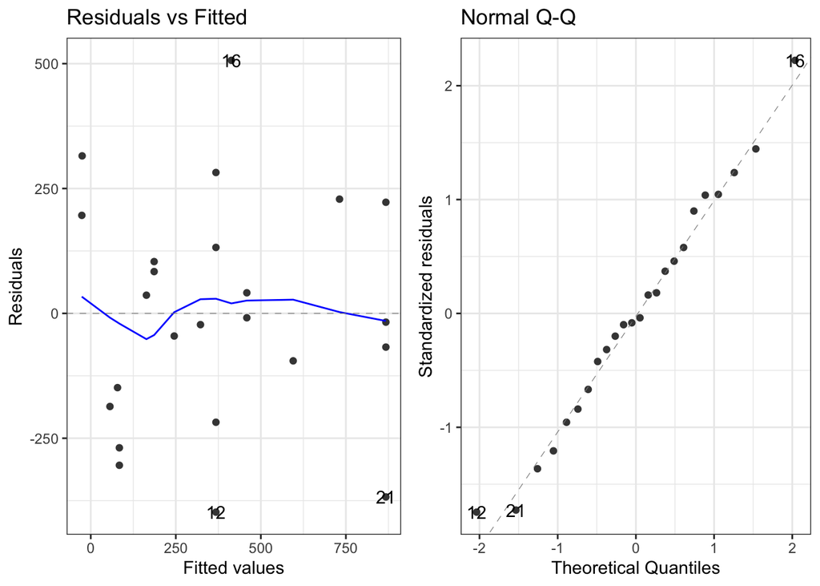